# Lab 07: `R` tools for writing research papers

Maximilian Haag

Constantin Kaplaner

16.01.2022

This session will introduce some features and `R` packages that can help you write your term paper. This lab file is written in RMarkdown, which in itself is a technique you can use to produce paper in a variety of output formats. We will first take a look at RMarkdown and how you can create your own documents. Many times you will use tables and plots to visualize your results and give the reader a better understanding of what’s going on. That’s what we will be looking at for the remainder of the lab session.

# RMarkdown

RMarkdown documents are a type of document that allow us to

1. combine text and code, resp. data visualizations, into a single file when writing papers
2. can produce a variety of different output formats from that file

This allows us to keep both our data presentation and our writing process in one place. At the same time, RMarkdown allows us to separate content and styling, so that we can focus on the content and handle styling using few options and commands.

We will look at how we can create a RMarkdown document in RStudio, how we can edit it and create polished documents. Finally, we will look at some tips and best practices. We will only be able to cover a small part of the RMarkdown functionality in this lab. Thus, make sure to check out [RStudio’s introduction to RMarkdown](https://rmarkdown.rstudio.com/lesson-1.html) as well as [R Markdown: The Definitive Guide](https://bookdown.org/yihui/rmarkdown/) for more detailed look. Also make sure to check out the [RMarkdown cheat sheet](https://github.com/rstudio/cheatsheets/raw/main/rmarkdown-2.0.pdf) for a quick and easy reference of the basics.

Getting started with RMarkdown can take some time and might be confusing at first, but once you have your workflow figured out it will make it significantly easier to create good looking, professional documents for your research and term papers.

## How to create a RMarkdown document in RStudio

RStudio allows you to create a new RMarkdown document straight from the user interface by navigating to `File > New File > R Markdown...` in the menu. The opening dialog will allow you to select a document type (you can also create presentations amongst other things), set a title and an author name. Once you confirm the dialog window, you will be presented with an automatically generated template.

## Basics: Editing RMarkdown documents

RMarkdown files consists of a ‘header’ and the content. The header is marked by `---` and contains information in [YAML](https://www.cloudbees.com/blog/yaml-tutorial-everything-you-need-get-started) format. Contained in the header are the ‘settings’ of the document. Here’s an example:

```
---
title: "My paper"
author: "Maximilian Haag"
date: "1/20/2023"
output: pdf_document
---
```

This YAML header specifies that we want the title of our document to be ‘My paper’. ‘Maximilian Haag’ is the author of the document and the document date is “1/20/2023”. Finally, `output` specifies that we want a PDF document for our finished document. You can test what this will result in right away by clicking on the `Knit` button on top of the editor (you will need to save your document first). Take some time to check out the produced document.

The other part of the RMarkdown document is our content. As you can see, RStudio has also created some content for us already. The content can consist of text and regular `R` code. Code is contained in the grey boxes that start with `` ```{r}``` `` and end with `` ``` ``. The code goes right in between: To execute these “code chunks” you can either click the little green ‘play’ button in the upper right hand corner of every chunk. In an RMarkdown document, code chunks are often used to display tables and plots (see below for more on that).

Next, compare your created RMarkdown file with the produced output file. You will notice that not all code chunks show up in the output document and others have created additional content. This is controlled by additional argument in the line where we define or ‘open’ the code chunk, e.g. `include=FALSE` hides a code chunk for when we only want to perform an action that we might need throughout the document but is not relevant to the reader, such as loading data or defining a function. By default, the code chunk and its output will be printed. Sometimes we only want to include the output as with the plot in the example (`echo=FALSE`) or only the code (`echo=TRUE, results='hide'`). You can find and overview of the available code chunk options [here](https://bookdown.org/yihui/rmarkdown/r-code.html).

Code chunks behave just like a normal R script would. E.g., you can create variables and use them throughout the document. This means you could, e.g., load some data in none code chunk and then use it in another. The code chunks have access to the same environment, meaning your variables and data can be shared between code chunks.

Looking at the text surrounding the code chunks, you will notice that it looks different from what you see in Word and similar text processors. This is because we use Markdown to format our text. Markdown is what we call a *markup* (confusing, I know) language. Markup languages allow us to structure and format written text using additional statements (remember HTML?). For example, you can mark a (first-level) headline in Markdown by typing `# Title of your headline` and a second level sub-headline with `## This is the title of your headline`. This allows us to create a clearly structured document and formatted document without worrying about styling. Take a look at this [Markdown Cheatsheet](https://www.markdownguide.org/cheat-sheet/) to get familiar with the Markdown *syntax*.

## Producing documents

As already mentioned, RMarkdown can produce output (mainly documents and presentations) in a variety of formats You alter the look and formatting of these document by providing additional options in the YAML header. A comprehensive overview for documents and the available options by format can be found [here](https://bookdown.org/yihui/rmarkdown/documents.html) (navigate to your output format of choice in the menu bar).

Take some time to play around with the different formats and options.

## Best practices and advanced techniques

### Keep your data an and analysis presentation separate

When writing papers using RMarkdown it is generally advisable to *separate your concerns*, i.e. your data analysis and your write up or presentation of your results. Nevertheless, we can profit from using RMarkdown as it allows us to still access our results. Say, e.g., you have created a dataset that you want to showcase using tables an plots. You’ll want to compile your dataset in a separate file and save the dataset to your disk, e.g. in `.csv` format. You can then load this data in your RMarkdown document (using `read.csv()` as we have already done many times) and work with the data throughout the document.

If you have, e.g., ran a regression analysis and wanted to showcase the results in a regression table, you could perform the analysis in a separate file, e.g. `analysis.R`, complete with loading the data and running your commands in this file. To be able to access the results you produce in this file, you can ‘load’ the script into your RMarkdown document by using the `source()` function in a code chunk, like so:

```r
source('path/to/analysis.R')
```

You can then access all variables and objects you create in `analysis.R` in your RMarkdown document.

Note: Sourcing files is only advisable if the actions performed in the sourced file are not extensive and resource-intensive as this will significantly increase the time it takes to render your document. For large analysis it is best to go with the route mentioned above and same intermediary states in files. For file structures that exceed the simple two dimensional structure of a flat dataset table, you can use [`.Rdata` files](https://bookdown.org/ndphillips/YaRrr/rdata-files.html).

### Referencing and citing literature

Similarly to how we can reference tables and figures in our text, we can also cite literature in RMarkdown. For this you will need to export your library (i.e. the records of the texts you want to cite) into a `.bib` file (you can do this in most literature management programs), which we specify in the YAML header. Once we have done that, we can reference literature using *citekeys*. RMarkdown will then automatically translate these citekeys into citations in your preferred citation format and, depending on said format, add them to your reference list for the document. For more on the setup and how to cite, see the [RMarkdown Cookbook](https://bookdown.org/yihui/rmarkdown-cookbook/bibliography.html).

If you use Zotero you can use following code to automatically create a references file based on the papers you selected in Zotero:

```r
remotes::install_github("paleolimbot/rbbt")
bib <- rbbt::bbt_bib_selected(translator = "biblatex", .action = bbt_print)

cat(bib, file = "references.bib")
```

# Tables

Unlike other statistical suites, such as STATA, there is no unified way of creating tables in `R`. However, there are many packages available for almost any kind of need you have with regards to the input and the output format. This means that, depending on *what* you would like to show in a table and where you want to use it (think Word, LaTeX or even html formats), you might use different packages. Here, we will focus on the `flextable` package since it can handle a variety of different output formats (HTML, Word, PDF via RMarkdown and PowerPoint), can be used with the pipe (`%>%`) operator and can be integrated in an RMarkdown document.

The package author provides a comprehensive [user documentation](https://ardata-fr.github.io/flextable-book/) that you can refer to in case you want to look up a particular use case.

```r
# install the package
install.packages('flextable')
```

## Creating tables

We gonna create a simple example for an regression table. For this, we will use the `penguins` data set and the `lm` function to estimate a linear model.

```r
# load the package
library(tidyverse)
library(tidymodels)
library(flextable)

pen <- palmerpenguins::penguins
lm_pen <- lm(bill_length_mm ~ body_mass_g + island, data = pen)
```

`flextable` uses normal data frames as inputs. To get a nice output from our model, we use the `tidy()` function from the `tidymodels` package.

```r
lm_pen %>%
  tidy()
```

```
## # A tibble: 4 × 5
##   term            estimate std.error statistic  p.value
##   <chr>              <dbl>     <dbl>     <dbl>    <dbl>
## 1 (Intercept)     21.7      1.65         13.2  2.21e-32
## 2 body_mass_g      0.00499  0.000343     14.5  1.66e-37
## 3 islandDream      3.91     0.582         6.72 7.56e-11
## 4 islandTorgersen -1.27     0.722        -1.76 7.88e- 2
```

This gives us a tidy data frame of our regression model that we can use to create our table. To create a table we simply have to use the `flextable` function.

```r
lm_pen %>%
  tidy() %>%
  flextable()
```

| term | estimate | std.error | statistic | p.value |
| --- | --- | --- | --- | --- |
| (Intercept) | 21.742896492 | 1.64687556 | 13.202513 | 0.0000000000000000000000000000000221422356158 |
| body_mass_g | 0.004986111 | 0.00034312 | 14.531683 | 0.0000000000000000000000000000000000001656434 |
| islandDream | 3.911898228 | 0.58180152 | 6.723768 | 0.0000000000755906049561552410357262184843145 |
| islandTorgersen | -1.272300637 | 0.72165073 | -1.763042 | 0.0787969857171670895468196249566972255706787 |

While this creates a first table, there are some things we can do better. First off, we often report only the first two decimals for our values. We can use the `round()` function to round our values. One problem when using `round()` for creating tables is, that it cut offs decimals when they end in 0. See the example below:

```r
round(1.100, digits = 2)
```

```
## [1] 1.1
```

Here 1.100 gets rounded to 1.1. In tables, we normally aim to report all values with the same amount of decimals. To solve this problem, we can use the `format()` function and fix the decimals to 2 by defining `nsmall = 2`:

```r
format(round(1.100, digits = 2), nsmall = 2)
```

```
## [1] "1.10"
```

If we apply this to our table we get the following:

```r
lm_pen %>%
  tidy() %>%
  select(term, estimate, std.error, p.value) %>%
  mutate(estimate = format(round(estimate, 2),nsmall = 2),
         std.error = format(round(std.error, 2),nsmall = 2),
         p.value = format(round(p.value, 2),nsmall = 2)) %>%
  flextable()
```

| term | estimate | std.error | p.value |
| --- | --- | --- | --- |
| (Intercept) | 21.74 | 1.65 | 0.00 |
| body_mass_g | 0.00 | 0.00 | 0.00 |
| islandDream | 3.91 | 0.58 | 0.00 |
| islandTorgersen | -1.27 | 0.72 | 0.08 |

We can do some further adjustments by adding stars to mark significant results, renaming the columns to our desired names and setting a caption.

```r
lm_pen %>%
  tidy() %>%
  select(term, estimate, std.error, p.value) %>%
  mutate(estimate = format(round(estimate, 2),nsmall = 2),
         std.error = format(round(std.error, 2),nsmall = 2),
         p.value = format(round(p.value, 2),nsmall = 2)) %>%
  mutate(p.value = if_else(p.value <= 0.01, paste0(p.value, "***"), p.value)) %>%
  rename(` ` = term,
         coefficient = estimate,
         se = std.error,
         `p-value` = p.value) %>%
  flextable() %>%
  autofit() %>%
  set_caption("Regression table")
```

Regression table

|  | coefficient | se | p-value |
| --- | --- | --- | --- |
| (Intercept) | 21.74 | 1.65 | 0.00*** |
| body_mass_g | 0.00 | 0.00 | 0.00*** |
| islandDream | 3.91 | 0.58 | 0.00*** |
| islandTorgersen | -1.27 | 0.72 | 0.08 |

To include the table in your term paper you can simple put the code into a code chunk in your Rmardkown file.

## Referencing tables

You should give every table you are creating a unique label To do so, you have to pass a name to the code chunk where you create the table. This would look like this: `{r name_of_table}`

To references the table simply write `\@ref(tab:name_of_table)` in text where you want to reference your table.

# Figures

There are two ways you can include figures in your markdown file. You could plot it directly in the Rmarkdown file, or you could save it in your script and include it as an image.

## Creating figures

First, you can include them directly through code. We keep with our regression output from before, and we will create a coefficient plot. Again we use the `tidy` function but this time we also want confidence intervals so we can plot them in our coefficient plot.

For the plot itself we will use `geom_pointrange()`. This creates a point plot with error bars. For the error bars, we set a `xmin` and `xmax` value that correspond to our confidence intervals.

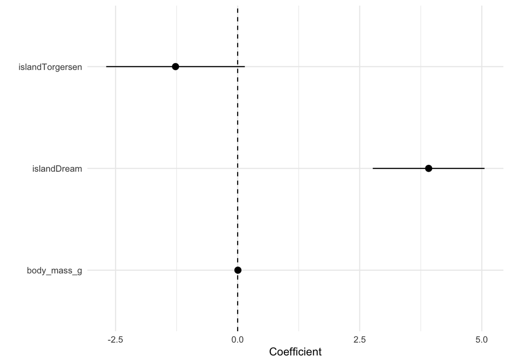

```r
lm_pen %>%
  tidy(conf.int = T, conf.level = .95) %>%
  filter(term != "(Intercept)") %>%
  ggplot(aes(x=estimate, y=term,
             xmin = conf.low,
             xmax = conf.high))+
  geom_vline(xintercept = 0, linetype = 2)+
  geom_pointrange()+
  theme_minimal()+
  xlab("Coefficient")+
  ylab("")
```

Including this code directly in our Rmarkdown would render our plot. Alternatively we can save the plot as `pdf` and include the pdf. When using `ggplot` we can use `ggsave` for this. First we save our plot to the object `coef_plot_pen`, then we save it with `ggsave()`

```r
coef_plot_pen <- lm_pen %>%
  tidy(conf.int = T, conf.level = .95) %>%
  filter(term != "(Intercept)") %>%
  ggplot(aes(x=estimate, y=term,
             xmin = conf.low,
             xmax = conf.high))+
  geom_vline(xintercept = 0, linetype = 2)+
  geom_pointrange()+
  theme_minimal()+
  xlab("Coefficient")+
  ylab("")

ggsave(coef_plot_pen, filename = "coef_plot_pen.pdf", width = 5, height = 5)
```

We can then include the plot by using the `include_graphics()` function in the `knitr` package:

```r
knitr::include_graphics("coef_plot_pen.pdf")
```

## Referencing plots

Similar to tables, we should also name our plots in the code chunk: `{r name_of_figure}`

Additionally, we need to include the figure caption in the code chunk instead of in the code as we did with flextable:

`{r name_of_figure, fig.cap="Caption for our plot"}`.

You can now reference the figure similar to a table by using: `\@ref(fig:name_of_figure)`.